# A quick introduction to machine learning in R with caret

See http://www.sharpsightlabs.com/quick-introduction-machine-learning-r-caret/

If youâve been using R for a while, and youâve been working with basic data visualization and data exploration techniques, the next logical step is to start learning some machine learning.

To help you begin learning about machine learning in R, Iâm going to introduce you to an R package: the caret package. Weâll build a very simple machine learning model as a way to learn some of caretâs basic syntax and functionality.

But before diving into caret, letâs quickly discuss what machine learning is and why we use it.

### What is machine learning?

Machine learning is the study of data-driven, computational methods for making inferences and predictions.

Without going into extreme depth here, letâs unpack that by looking at an example.

### A simple example

Imagine that you want to understand the relationship between car weight and car fuel efficiency (I.e., miles per gallon); how is fuel efficiency effected by a carâs weight?

To answer this question, you could obtain a dataset with several different car models, and attempt to identify a relationship between weight (which weâll call wt) and miles per gallon (which weâll call mpg).

A good starting point would be to simply plot the data, so first, weâll create a scatterplot using Râs ggplot: require(ggplot2)

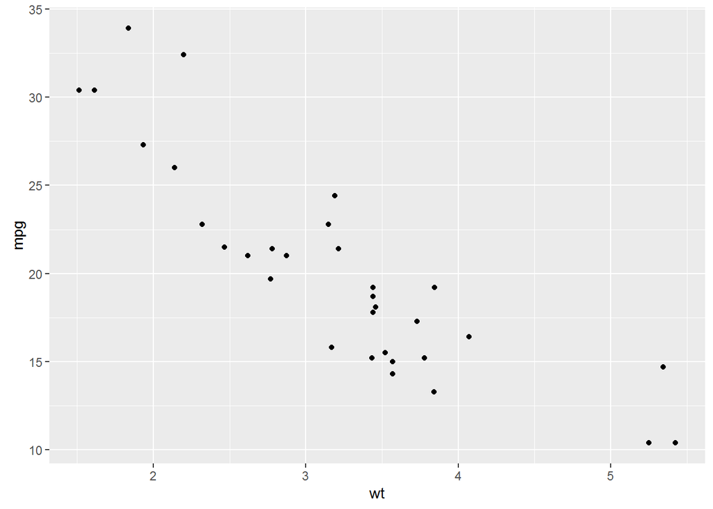

```r
library(ggplot2)
ggplot(data = mtcars, aes(x = wt, y = mpg)) +
  geom_point()
```

Just examining the data visually, itâs pretty clear that thereâs some relationship. But if we want to make more precise claims about the relationship between wt and mpg, we need to specify this relationship mathematically. So, as we press forward in our analysis, weâll make the assumption that this relationship can be described mathematically; more precisely, weâll assume that this relationship can be described by some mathematical function, f(x). In the case of the above example, weâll be making the assumption that âmiles per gallonâ can be described as a function of âcar weightâ.

Assuming this type of mathematical relationship, machine learning provides a set of methods for identifying that relationship. Said differently, machine learning provides a set of computational methods that accept data observations as inputs, and subsequently estimate that mathematical function, f(x); machine learning methods learn the relationship by being trained with an input dataset.

Ultimately, once we have this mathematical function (a model), we can use that model to make predictions and inferences.

### How much math you really need to know

What I just wrote in the last few paragraphs about âestimating functionsâ and âmathematical relationshipsâ might cause you to ask a question: âhow much math do I need to know to do machine learning?â

Ok, here is some good news: to implement basic machine learning techniques, you donât need to know much math.

To be clear, there is quite a bit of math involved in machine learning, but most of that math is taken care of for you. What I mean, is that for the most part, R libraries and functions perform the mathematical calculations for you. You just need to know which functions to use, and when to use them.

Hereâs an analogy: if you were a carpenter, you wouldnât need to build your own power tools. You wouldnât need to build your own drill and power saw. Therefore, you wouldnât need to understand the mathematics, physics, and electrical engineering principles that would be required to construct those tools from scratch. You could just go and buy them âoff the shelf.â To be clear, youâd still need to learn how to use those tools, but you wouldnât need a deep understanding of math and electrical engineering to operate them.

When youâre first getting started with machine learning, the situation is very similar: you can learn to use some of the tools, without knowing the deep mathematics that makes those tools work.

Having said that, the above analogy is somewhat imperfect. At some point, as you progress to more advanced topics, it will be very beneficial to know the underlying mathematics. My argument, however, is that in the beginning, you can still be productive without a deep understanding of calculus, linear algebra, etc. In any case, Iâll be writing more about âhow much math you needâ in another blog post.

Ok, so you donât need to know that much math to get stared, but youâre not entirely off the hook. As I noted above, you still need to know how to use the tools properly.

In some sense, this is one of the challenges of using machine learning tools in R: many of them be difficult to use.

R has many packages for implementing various machine learning methods, but unfortunately many of these tools were designed separately, and they are not always consistent in how they work. The syntax for some of the machine learning tools is very awkward, and syntax from one tool to the next is not always the same. If you donât know where to start, machine learning in R can become very confusing.

This is why I recommend using the caret package to do machine learning in R.

### A quick introduction to caret

For starters, letâs discuss what caret is.

The caret package is a set of tools for building machine learning models in R. The name âcaretâ stands for Classification And REgression Training. As the name implies, the caret package gives you a toolkit for building classification models and regression models. Moreover, caret provides you with essential tools for:

â Data preparation, including: imputation, centering/scaling data, removing correlated predictors, reducing skewness â Data splitting â Model evaluation â Variable selection

#### Caret simplifies machine learning in R

While caret has broad functionality, the real reason to use caret is that itâs simple and easy to use.

As noted above, one of the major problems with machine learning in R is that most of Râs different machine learning tools have different interfaces. They almost all âworkâ a little differently from one another: the syntax is slightly different from one modeling tool to the next; tools for different parts of the machine learning workflow donât always âwork wellâ together; tools for fine tuning models or performing critical functions may be awkward or difficult to work with. Said succinctly, R has many machine learning tools, but they can be extremely clumsy to work with.

Caret solves this problem. To simplify the process, caret provides tools for almost every part of the model building process, and moreover, provides a common interface to these different machine learning methods.

For example, caret provides a simple, common interface to almost every machine learning algorithm in R. When using caret, different learning methods like linear regression, neural networks, and support vector machines, all share a common syntax (the syntax is basically identical, except for a few minor changes).

Moreover, additional parts of the machine learning workflow â like cross validation and parameter tuning â are built directly into this common interface.

To say that more simply, caret provides you with an easy-to-use toolkit for building many different model types and executing critical parts of the ML workflow. This simple interface enables rapid, iterative modeling. In turn, this iterative workflow will allow you to develop good models faster, with less effort, and with less frustration.

#### Caretâs syntax

Now that youâve been introduced to caret, letâs return to the example above (of mpg vs wt) and see how caret works.

Again, imagine you want to learn the relationship between mpg and wt. As noted above, in mathematical terms, this means identifying a function, f(x), that describes the relationship between wt and mpg.

In terms of our modeling effort, this means that weâll be using linear regression to build our machine learning model.

Without going into the details of linear regression (Iâll save that for another blog post), letâs look at how we implement linear regression with caret.

**The train() function**

The core of caretâs functionality is the train() function.

train() is the function that we use to âtrainâ the model. That is, train is the function that will âlearnâ the relationship between mpg and wt.

Letâs take a look at this syntactically.

Here is the syntax for a linear regression model, regressing mpg on wt.

```r
#~~~~~~~~~~~~~~~~~~~~~~~~~~
# Build model using train()
#~~~~~~~~~~~~~~~~~~~~~~~~~~

require(caret)
model.mtcars_lm <- train(mpg ~ wt
                        ,data = mtcars
                        ,method = "lm"
                        )
```

Thatâs it. The syntax for building a linear regression is extremely simple with caret.

Now that we have a simple model, letâs quickly extract the regression coefficients and plot the model (i.e., plot the linear function that describes the relationship between mpg and wt).

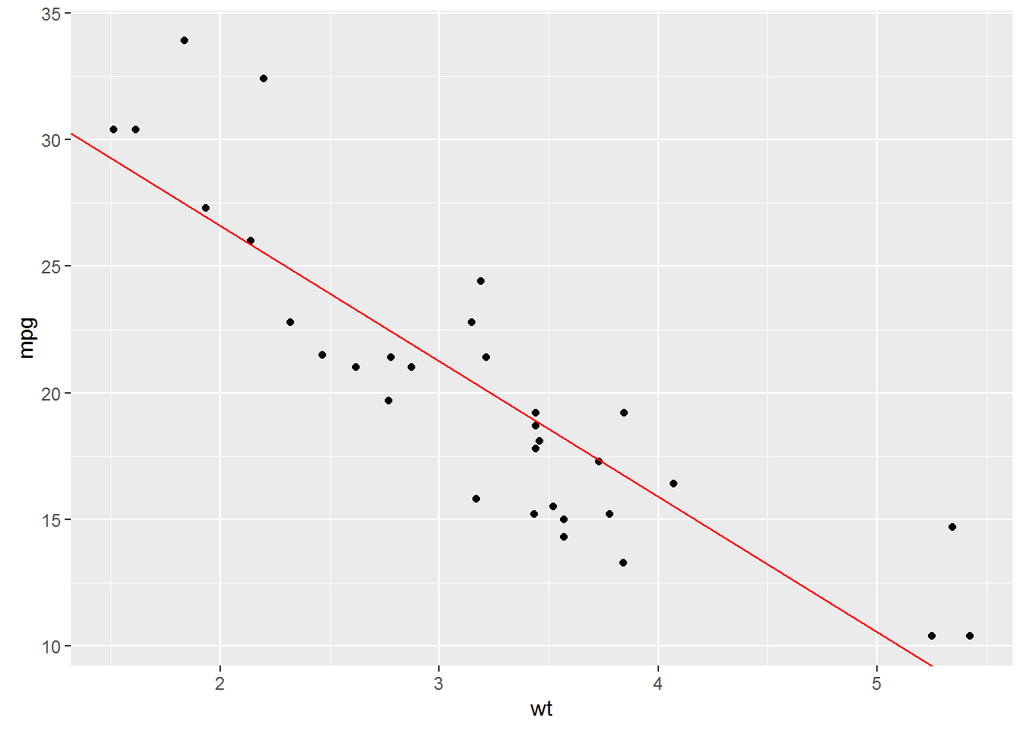

```r
#~~~~~~~~~~~~~~~~~~~~~~~~~~
# Retrieve coefficients for
#  - slope
#  - intercept
#~~~~~~~~~~~~~~~~~~~~~~~~~~

coef.icept <- coef(model.mtcars_lm$finalModel)[1]
coef.slope <- coef(model.mtcars_lm$finalModel)[2]


#~~~~~~~~~~~~~~~~~~~~~~~~~~~~~~~~~~~~~
# Plot scatterplot and regression line
#  using ggplot()
#~~~~~~~~~~~~~~~~~~~~~~~~~~~~~~~~~~~~~

ggplot(data = mtcars, aes(x = wt, y = mpg)) +
  geom_point() +
  geom_abline(slope = coef.slope, intercept = coef.icept, color = "red")
```

Now, letâs look more closely at the syntax and how it works.

When training a model using train(), you only need to tell it a few things:

â The dataset youâre working with â The target variable youâre trying to predict (e.g., the mpg variable) â The input variable (e.g., the wt variable) â The machine learning method you want to use (in this case âlinear regressionâ)

**Formula notation**

In caretâs syntax, you identify the target variable and input variables using the âformula notation.â

The basic syntax for formula notation is y ~ x, where y is your target variable, and x is your predictor.

Effectively, y ~ x tells caret âI want to predict y on the basis of a single input, x.â

Now, with this knowledge about caretâs formula syntax, letâs reexamine the above code. Because we want to predict mpg on the basis of wt, we use the formula mpg ~ wt. Again, this line of code is the âformulaâ that tells train() our target variable and our input variable. If we translate this line of code into English, weâre effectively telling train(), âbuild a model that predicts mpg (miles per gallon) on the basis of wt (car weight).â

**The data = parameter**

The train() function also has a data = parameter. This basically tells the train() function what dataset weâre using to build the model. Said differently, if weâre using the formula mpg ~ wt to indicate the target and predictor variables, then weâre using the data = parameter to tell caret where to find those variables.

So basically, data = mtcars tells the caret function that the data and the relevant variables can be found in the mtcars dataset.

**The method = parameter**

Finally, we see the method = parameter. This parameter indicates what machine learning method we want to use to predict y. In this case, weâre building a linear regression model, so we are using the argument âlmâ.

Keep in mind, however, we could select a different learning method. Although itâs beyond the scope of this blog post to discuss all of the possible learning methods that we could use here, there are many different methods we could use. For example, if we wanted to use the k-nearest neighbor technique, we could use the âknnâ argument instead. If we did that, train() would still predict mpg on the basis of wt, but would use a different statistical technique to make that prediction. This would yield a different model; a model that makes different predictions.

Again, itâs beyond the scope of this post to discuss all of the different model types. However, as you learn more about machine learning, and want to try out more advanced machine learning techniques, this is how you can implement them. You simply change the learning method by changing the argument of the method = parameter.

This is a good place to reiterate one of caretâs primary advantages: switching between model types is extremely easy when we use caretâs train() function. Again, if you want to use linear regression to model your data, you just type in âlmâ for the argument to method =; if you want to change the learning method to k-nearest neighbor, you just replace âlmâ with âknnâ.

Caretâs syntax allows you to very easily change the learning method. In turn, this allows you to âtry outâ and evaluate many different learning methods rapidly and iteratively. You can just re-run your code with different values for the method parameter, and compare the results for each method.